# Algorithmic Justice and SVM Models with

## A Question For You

> Is the accuracy level higher or lower? 💹 Please respond to this question in your write-up.

```r
# Now exclude priors from the model....

train_subset_no_priors <- train_subset %>% select(-priors_count)

train_svm_no_priors_results <- train(Recidivated ~., data = train_subset_no_priors,
                  method = "svmLinear",
                  trControl = trctrl,
                  preProcess = c("center", "scale"),
                  tuneLength = 10)

print(train_svm_no_priors_results)
```

```
## Support Vector Machines with Linear Kernel
##
## 4622 samples
##    6 predictor
##    2 classes: 'notRecidivate', 'Recidivate'
##
## Pre-processing: centered (11), scaled (11)
## Resampling: Cross-Validated (10 fold)
## Summary of sample sizes: 4160, 4160, 4160, 4159, 4160, 4160, ...
## Resampling results:
##
##   Accuracy   Kappa
##   0.6107683  0.2084058
##
## Tuning parameter 'C' was held constant at a value of 1
```

```r
# Let's compare the model performance with and without priors...
print(
  str_c("The SVM model that includes priors had an Accuracy of: ", round(train_svm_results$results$Accuracy, 6), " while the model that excluded priors had an Accuracy of: ", round(train_svm_no_priors_results$results$Accuracy, 6))
  )
```

```
## [1] "The SVM model that includes priors had an Accuracy of: 0.656639 while the model that excluded priors had an Accuracy of: 0.610768"
```

As shown above, Accuracy declines when the **priors_count** feature is removed from the model, as does the kappa statistic. Kappa is designed to account for the fact that in a [classification problem](https://vitalflux.com/classification-problems-real-world-examples), some percentage of the observations are likely to be **correctly** classified by chance and attempts to provide [an indicator of predictive capacity](https://www.kaggle.com/general/185898) that accounts for this phenomenon. Note that for kappa, 1 means perfect agreement and 0 is chance agreement. One rule-of-thumb suggests that kappa values of 0.21-0.40 is fair, 0.41- 0.60 is moderate, 0.61-0.80 is substantial, and 0.81-1.00 is almost perfect agreement.

### Assess Accuracy and Generalizability

Now let’s use the SVM model **that does not include race as a feature** to predict recidivism outcomes for our test data 😄

```r
# Best fitting SVM model that excludes race...

test_subset_no_race <- test %>% dplyr::select(sex, age, age_cat,
                                juv_other_count, length_of_stay,
                                priors_count, Recidivated)


test_svm_no_race_results <- predict(train_svm_no_race_results, test_subset_no_race)


caret::confusionMatrix(as_factor(test_svm_no_race_results), test_subset_no_race$Recidivated, positive = "Recidivate")
```

```
## Confusion Matrix and Statistics
##
##                Reference
## Prediction      notRecidivate Recidivate
##   notRecidivate           597        292
##   Recidivate              243        408
##
##                Accuracy : 0.6526
##                  95% CI : (0.6282, 0.6764)
##     No Information Rate : 0.5455
##     P-Value [Acc > NIR] : < 2e-16
##
##                   Kappa : 0.2953
##
##  Mcnemar's Test P-Value : 0.03797
##
##             Sensitivity : 0.5829
##             Specificity : 0.7107
##          Pos Pred Value : 0.6267
##          Neg Pred Value : 0.6715
##              Prevalence : 0.4545
##          Detection Rate : 0.2649
##    Detection Prevalence : 0.4227
##       Balanced Accuracy : 0.6468
##
##        'Positive' Class : Recidivate
##
```

```r
# This chunk recreates the prediction above, but that is okay
# because above we wanted the confusion matrix...

testProbs <-
  data.frame(Observed = test$recidivatedNumeric,
             Predicted = predict(train_svm_no_race_results, test_subset_no_race, type = "raw"),
             Race = test$race2)
```

The `caret::confusionMatrix` function produces a variety of metrics that help us to assess performance of the classification model. In the actual [confusion matrix](https://en.wikipedia.org/wiki/Confusion_matrix) at the top of the output, the numbers on the diagonal represent correctly classified observations, while the numbers off the diagonal represent mis-classified observations. The **accuracy rate** is given along with a confidence interval and p-value. The [**kappa statistic**](https://thedatascientist.com/performance-measures-cohens-kappa-statistic/) is also included. Note that for kappa, 1 means perfect agreement and 0 is chance agreement. One rule-of-thumb suggests that kappa values of 0.21-0.40 is fair, 0.41- 0.60 is moderate, 0.61-0.80 is substantial, and 0.81-1.00 is almost perfect agreement. We can use *dplyr* to visualize the components of the confusion matrix as well.

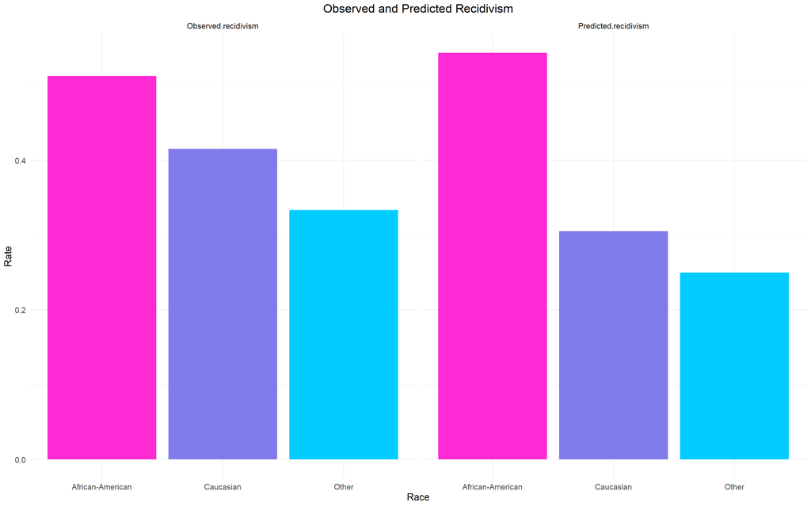

```r
# Visualize observed and predicted recidivism by race...

testProbs %>%
  mutate(Predicted.integer = if_else(Predicted == "Recidivate", 1, 0)) %>%
  group_by(Race) %>%
  summarize(Observed.recidivism = sum(Observed) / n(),
            Predicted.recidivism = sum(as.numeric(Predicted.integer)) / n()) %>%
  pivot_longer(cols = ends_with("ism"), names_to = "Type", values_to = "Value") %>%
  ggplot(aes(x = Race, y = Value)) +
    geom_bar(aes(fill = Race), position = "dodge", stat = "identity") +
    scale_fill_manual(values = palette_3_colors) +
    facet_wrap(~Type) +
    labs(title = "Observed and Predicted Recidivism", x = "Race", y = "Rate") +
    theme_minimal() +
    theme(legend.position = "none", plot.title = element_text(hjust = 0.5),
              text = element_text(size = 14))
```

```r
# Visualize in tabular format...
kbl(
  (testProbs %>%
  mutate(Predicted.integer = if_else(Predicted == "Recidivate", 1, 0)) %>%
  group_by(Race) %>%
  summarize(Observed.recidivism = sum(Observed) / n(),
            Predicted.recidivism = sum(as.numeric(Predicted.integer)) / n()) %>%
  pivot_longer(cols = ends_with("ism"), names_to = "Type", values_to = "Value")),
  digits = 3, align = "lccrr", caption = "Observed Versus Predicted Recidivism Rates by Race") %>%
  kable_paper("hover", full_width = TRUE)
```

Observed Versus Predicted Recidivism Rates by Race

| Race | Type | Value |
| --- | --- | --- |
| African-American | Observed.recidivism | 0.513 |
| African-American | Predicted.recidivism | 0.544 |
| Caucasian | Observed.recidivism | 0.415 |
| Caucasian | Predicted.recidivism | 0.305 |
| Other | Observed.recidivism | 0.333 |
| Other | Predicted.recidivism | 0.250 |

```r
# Calculate false positives/negatives and true positives/negatives...
testProbs <- testProbs %>%
  mutate(Predicted.integer = if_else(Predicted == "Recidivate", 1, 0),
        Count_TN = if_else((Observed == 0 & Predicted.integer == 0), 1, 0),
        Count_TP = if_else((Observed == 1 & Predicted.integer == 1), 1, 0),
        Count_FN = if_else((Observed == 1 & Predicted.integer == 0), 1, 0),
        Count_FP = if_else((Observed == 0 & Predicted.integer == 1), 1, 0))


# Display false positives/negatives and true positives/negatives as rates...
testProbs %>%
  group_by(Race) %>%
  summarize(Rate_TP = sum(Count_TP) / (sum(Count_TP) + sum(Count_FN) + sum(Count_TN) +  sum(Count_FP)),
            Rate_FP = sum(Count_FP) / (sum(Count_FP) + sum(Count_TN) + sum(Count_TP) +  sum(Count_FN)),
            Rate_FN = sum(Count_FN) / (sum(Count_FN) + sum(Count_TP) + sum(Count_TN) +  sum(Count_FP)),
            Rate_TN = sum(Count_TN) / (sum(Count_TN) + sum(Count_FP) + sum(Count_TP) +  sum(Count_FN)))
```

| Race | Rate_TP | Rate_FP | Rate_FN | Rate_TN |
| --- | --- | --- | --- | --- |
| African-American | 0.3588163 | 0.1849568 | 0.1541307 | 0.3020962 |
| Caucasian | 0.1696607 | 0.1357285 | 0.2455090 | 0.4491018 |
| Other | 0.1403509 | 0.1096491 | 0.1929825 | 0.5570175 |

## A Question For You

> What (if anything) does your table or chart tell us about algorithmic bias in this context? Please respond to this question in your write-up.

## Feature Engineering

[figure not shown]

```r
train_subset_felony <- train %>% dplyr::select(sex, age, age_cat,
                                juv_other_count, length_of_stay,
                                priors_count, Recidivated, c_charge_degree)

train_svm_felony_results <- train(Recidivated ~., data = train_subset,
                  method = "svmLinear",
                  trControl = trctrl,
                  preProcess = c("center", "scale"),
                  tuneLength = 10)

print(train_svm_felony_results)
```

```
## Support Vector Machines with Linear Kernel
##
## 4622 samples
##    7 predictor
##    2 classes: 'notRecidivate', 'Recidivate'
##
## Pre-processing: centered (12), scaled (12)
## Resampling: Cross-Validated (10 fold)
## Summary of sample sizes: 4160, 4160, 4159, 4160, 4160, 4160, ...
## Resampling results:
##
##   Accuracy   Kappa
##   0.6559956  0.30059
##
## Tuning parameter 'C' was held constant at a value of 1
```

## A Question For You

> Did adding the type of offense (i.e., felony or misdemeanor) end up “moving the needle” in terms of predictive capacity? Please respond to this question in your write-up.

# Model Performance and Generalizability

The `trainControl` function can be accessed directly or from within the `train` function via the `trControl` argument. In the preceding examples we set up [10-fold cross-validation](https://towardsdatascience.com/why-and-how-to-cross-validate-a-model-d6424b45261f) which is something of a standard approach although the number of folds is arbitrary. This means the data will be split into 10 “slices” and each of those subsets will be “held out” in turn with the remaining 9 groups serving as a training set. We fit the model on this training set, calculate fit metrics (like Accuracy, MAE, or RMSE) when it is applied to the test set, then move on to the next group to be “held out”. This approach will use 90 percent of the data to create a model and 10 percent to test it. Then, we run the model again with a different 10 percent and repeat this until all the data has been used as both training and test data.

What happens when we set the method to **repeatedcv** in the code chunk below is that the 10-fold procedure is **repeated 3 times** using a different set of folds for each of the 3 cross-validation procedures. The goal of this is to provide more robust estimates of model performance, but keep in mind that **it is also more computationally expensive** to do this.

```r
fitControl <- trainControl(method = "repeatedcv", number = 10, repeats = 3)

train_svm_felony_results_repeated <- train(Recidivated ~., data = train_subset,
                  method = "svmLinear",
                  trControl = fitControl,
                  preProcess = c("center", "scale"),
                  tuneLength = 10)

print(train_svm_felony_results_repeated)
```

```
## Support Vector Machines with Linear Kernel
##
## 4622 samples
##    7 predictor
##    2 classes: 'notRecidivate', 'Recidivate'
##
## Pre-processing: centered (12), scaled (12)
## Resampling: Cross-Validated (10 fold, repeated 3 times)
## Summary of sample sizes: 4160, 4160, 4159, 4160, 4160, 4160, ...
## Resampling results:
##
##   Accuracy  Kappa
##   0.655993  0.3006109
##
## Tuning parameter 'C' was held constant at a value of 1
```

```r
# Visualize model fit over the 10 folds...
train_svm_felony_results_repeated$resample
```

| Accuracy | Kappa | Resample |
| --- | --- | --- |
| 0.6580087 | 0.3042434 | Fold01.Rep1 |
| 0.6926407 | 0.3711755 | Fold02.Rep1 |
| 0.6479482 | 0.2894829 | Fold03.Rep1 |
| 0.6796537 | 0.3472334 | Fold04.Rep1 |
| 0.6731602 | 0.3326637 | Fold05.Rep1 |
| 0.6341991 | 0.2578842 | Fold06.Rep1 |
| 0.6414687 | 0.2737598 | Fold07.Rep1 |
| 0.6515152 | 0.2896109 | Fold08.Rep1 |
| 0.6645022 | 0.3193613 | Fold09.Rep1 |
| 0.6277056 | 0.2425941 | Fold10.Rep1 |

[output cut: 20 more lines]

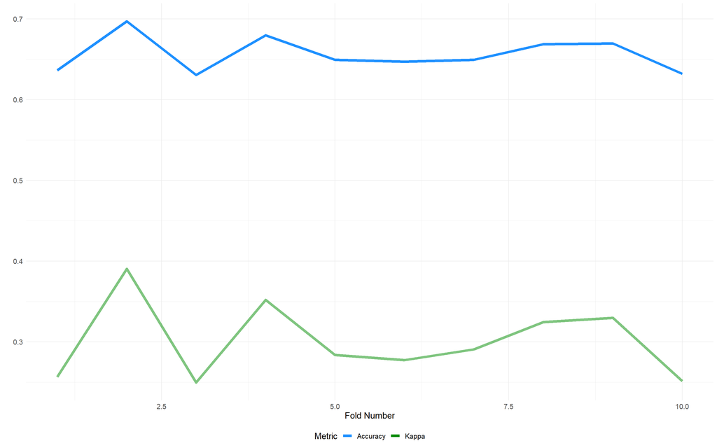

```r
ggplot() +
  geom_line(mapping = aes(y = train_svm_felony_results$resample$Accuracy, x = seq(1, 10, 1), color = "dodgerblue"), linewidth = 2) +
  geom_line(mapping = aes(y = train_svm_felony_results$resample$Kappa, x = seq(1, 10, 1), color = "green4"), alpha = 0.5, linewidth = 2) +
  scale_color_manual(name = "Metric", values = c("dodgerblue", "green4"), labels = c("Accuracy", "Kappa")) +
  xlab("Fold Number") + ylab("") +
  theme_minimal() +
  theme(legend.position = "bottom", plot.title = element_text(hjust = 0.5),
              text = element_text(size = 14))
```

The cross-validation output provides very important goodness of fit information. The value of each metric that is **reported in the default output** is actually the mean value across all *k* folds. The train function returns many objects `names(train_svm_felony_results_repeated)`, one of which is resample which provides goodness of fit for each of the *k* folds. The code chunk above displays these results and also plots them so we can decide if the predictive power of the model is relatively stable across the *k* folds to which it has been applied 😁

## Varying the Hyperparameters

This final section demonstrates how we can force *caret* to return information on model performance across different values of the SVM hyperparameter **C**. Right now, we are using the **tuneLength** argument of the `train` function to automatically try the specified number of values for the algorithm’s hyperparameter(s). Recall that we can look up the hyperparameters (i.e., Tuning Parameters) by visiting [this page](https://topepo.github.io/caret/available-models.html) of the documentation and that the **svmLinear** algorithm has only one—**Cost**.

```r
train_svm_felony_results_tuned <- train(Recidivated ~., data = train_subset,
                  method = "svmLinear",
                  trControl = trctrl,
                  preProcess = c("center", "scale"),
#                  tuneLength = 10,
                  tuneGrid = expand.grid(C = seq(0.1, 5, length = 10)))

print(train_svm_felony_results_tuned)
```

```
## Support Vector Machines with Linear Kernel
##
## 4622 samples
##    7 predictor
##    2 classes: 'notRecidivate', 'Recidivate'
##
## Pre-processing: centered (12), scaled (12)
## Resampling: Cross-Validated (10 fold)
## Summary of sample sizes: 4160, 4160, 4160, 4159, 4160, 4160, ...
## Resampling results across tuning parameters:
##
##   C          Accuracy   Kappa
##   0.1000000  0.6557773  0.2999272
##   0.6444444  0.6562097  0.3009606
##   1.1888889  0.6562097  0.3009606
##   1.7333333  0.6562097  0.3009606
##   2.2777778  0.6562097  0.3009606
##   2.8222222  0.6562097  0.3009606
##   3.3666667  0.6562097  0.3009606
##   3.9111111  0.6562097  0.3009606
##   4.4555556  0.6562097  0.3009606
##   5.0000000  0.6562097  0.3009606
##
## Accuracy was used to select the optimal model using the largest value.
## The final value used for the model was C = 0.6444444.
```

```r
# Display model fit over the 10 folds...
train_svm_felony_results_tuned$resample
```

| Accuracy | Kappa | Resample |
| --- | --- | --- |
| 0.6623377 | 0.3136000 | Fold02 |
| 0.6428571 | 0.2725451 | Fold07 |
| 0.6861472 | 0.3612335 | Fold01 |
| 0.6320346 | 0.2471820 | Fold05 |
| 0.6255411 | 0.2409254 | Fold06 |
| 0.7012987 | 0.3980967 | Fold10 |
| 0.6522678 | 0.2913153 | Fold04 |
| 0.6587473 | 0.3081972 | Fold08 |
| 0.6774892 | 0.3451858 | Fold09 |
| 0.6233766 | 0.2313253 | Fold03 |

```r
# Display and visualize model fit over selected values of C...
train_svm_felony_results_tuned$results
```

|  | C | Accuracy | Kappa | AccuracySD | KappaSD |
| --- | --- | --- | --- | --- | --- |
| 1 | 0.1000000 | 0.6557773 | 0.2999272 | 0.02484533 | 0.05224614 |
| 2 | 0.6444444 | 0.6562097 | 0.3009606 | 0.02629515 | 0.05525914 |
| 3 | 1.1888889 | 0.6562097 | 0.3009606 | 0.02629515 | 0.05525914 |
| 4 | 1.7333333 | 0.6562097 | 0.3009606 | 0.02629515 | 0.05525914 |
| 5 | 2.2777778 | 0.6562097 | 0.3009606 | 0.02629515 | 0.05525914 |
| 6 | 2.8222222 | 0.6562097 | 0.3009606 | 0.02629515 | 0.05525914 |
| 7 | 3.3666667 | 0.6562097 | 0.3009606 | 0.02629515 | 0.05525914 |
| 8 | 3.9111111 | 0.6562097 | 0.3009606 | 0.02629515 | 0.05525914 |
| 9 | 4.4555556 | 0.6562097 | 0.3009606 | 0.02629515 | 0.05525914 |
| 10 | 5.0000000 | 0.6562097 | 0.3009606 | 0.02629515 | 0.05525914 |

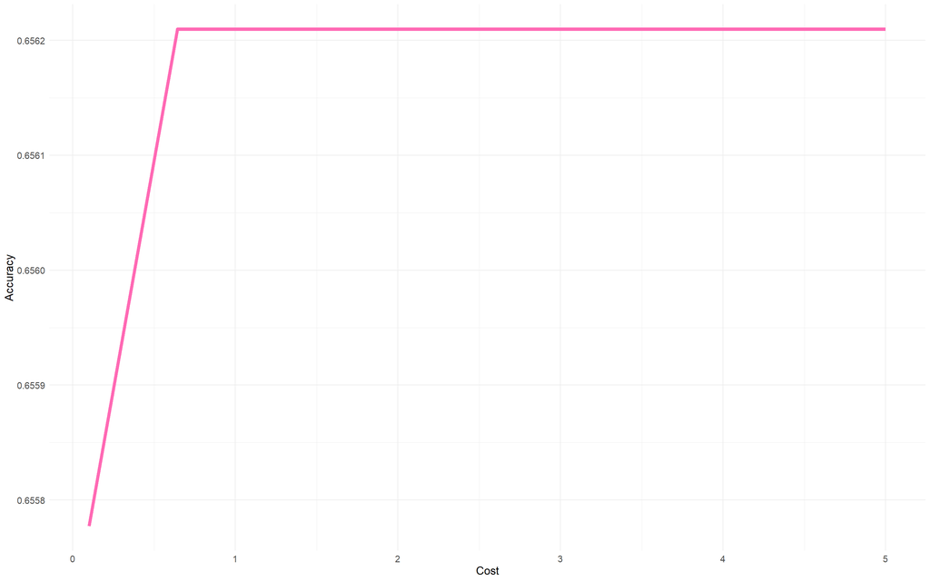

```r
ggplot() +
  geom_line(mapping = aes(y = train_svm_felony_results_tuned$results$Accuracy, x = train_svm_felony_results_tuned$results$C), color = "hotpink", linewidth = 2) +
    xlab("Cost") + ylab("Accuracy") +
  theme_minimal() +
  theme(legend.position = "bottom", plot.title = element_text(hjust = 0.5),
        text = element_text(size = 14))
```

Note that we can access the best-fitting value of the **Cost** parameter (that falls withing the search space) by accessing the `bestTune` component of the resulting object:

`train_svm_felony_results_tuned$bestTune`

## A Question For You

> Please discuss what you have learned about using predictive models like this within the criminal justice system in your write-up. Is there value in using techniques like this to determine whether bail is required (or the amount of bail) for individuals who have been arrested? Are there things that could be done to establish “guardrails” for tools like this?

### Exercise

This exercise asks you to adapt the code in the “Make Predictions” and “Decompose Confusion Matrix” chunks above so that you apply the best-fitting model that you have (i.e., that you trained using the **train_subset_felony** dataset) to the test data. You will need to make sure that the test set has the same features (i.e., `dplyr::select` function) as the **train_subset_felony** dataset. There is no need to set the method argument to **repeatedcv** here 😌

### Work Products

Please submit an R Notebook and knitted HTML file that shows your work and responses for each of the **Exercises** included in this lab exercise. Also, briefly comment on your experience with R during this lab exercise. Please **upload your report to Collab** by **5:00 pm on Friday April 7th**.

### Assessment Rubric

This Lab Exercise will be graded on a 100-point scale according to the rubric below:

**Length and formatting (10 pts)**

- Are the Lab Exercise responses provided in an acceptable format (e.g., R Notebook, rendered HTML file, etc.)?
- Is there enough explanatory text to evaluate the work?

**Clarity of writing and attention to detail (20 pts)**

- Is the text component clearly written? Please do not rely too heavily on bulleted lists.
- Are there more than one or two grammatical or typographical errors? Please perform a spelling/grammar check prior to submission.

**Technical Content (45 pts)**

- Are the requested graphics, tables, etc. included and intelligible?
- Does the submission explicitly and thoroughly respond to any questions posed?
- Please explain why you reached the conclusions you did when responding to the questions posed.

**Reflective Content (25 pts)**

- Does the response reflect on the procedures used (i.e., what am I clicking and why?)?
- Is there evidence that the student understands how the substance of the Lab Exercise relates to concepts from the lectures/readings and/or how the substance of the Lab Exercise might be applied in the work planners (or you personally) do?

© Bev Wilson 2023 | Department of Urban + Environmental Planning | University of Virginia